# Evaluate main models’ performance in held out outer folds for 1week and lead = 72 and v1

Author

John Curtin & Kendra Wyant

Published

July 4, 2024

### Code Status

In use with iterative improvement

### Notes

This is a generic script that reproduces the CV metrics for the best model configuration, calculates various performance metrics from that resampling, makes plots, and then fits the best config to the final sample to do feature importance.

This script is called by various studies, passing in the data_type, window, lead, and version.

### Set Up Environment

```r
study <- params$study
cv <- params$cv
window <- params$window
model <- params$model
lead <- params$lead
version <- params$version
```

Function conflicts

```r
# handle conflicts
options(conflicts.policy = "depends.ok")
devtools::source_url("https://github.com/jjcurtin/lab_support/blob/main/fun_ml.R?raw=true")
tidymodels_conflictRules()
```

Packages for script

```r
library(tidyverse)
library(tidymodels)
library(tidyposterior)
# library(SHAPforxgboost)
# library(rstanarm)

theme_set(theme_classic())
```

Source support functions

```r
# EDA
devtools::source_url("https://github.com/jjcurtin/lab_support/blob/main/fun_eda.R?raw=true")
```

```
ℹ SHA-1 hash of file is "c045eee2655a18dc85e715b78182f176327358a7"
```

```r
devtools::source_url("https://github.com/jjcurtin/lab_support/blob/main/format_path.R?raw=true")
```

```
ℹ SHA-1 hash of file is "a58e57da996d1b70bb9a5b58241325d6fd78890f"
```

```r
# CHTC support functions
devtools::source_url("https://github.com/jjcurtin/lab_support/blob/main/chtc/static_files/fun_chtc.R?raw=true")
```

```
ℹ SHA-1 hash of file is "75cc6f7b855da59c240908bd936834b4da01285b"
```

Absolute paths

```r
path_processed <- format_path(str_c("studydata/risk/data_processed/", study))
path_input <- format_path(str_c("studydata/risk/chtc/", study))
path_models <- format_path(str_c("studydata/risk/models/", study))
```

Chunk Defaults

### Model Performance Metrics

```r
preds_out <- read_rds(here::here(path_models, str_c("outer_preds_", window, "_",
                                                    lead, "_", version, "_",
                                                    cv, "_", model, ".rds")))
metrics_out <- read_rds(here::here(path_models, str_c("outer_metrics_", window, "_",
                                                      lead, "_", version, "_",
                                                    cv, "_", model, ".rds")))
```

#### Inner AUC

Best model configurations were selected using the median AUCs across 10 inner folds. 30 (3x10) models were selected.

This comes from metrics_out validation sets. Only used for auROC in validation sets

```r
metrics_out |> glimpse()
```

```
Rows: 30
Columns: 22
$ outer_split_num <int> 1, 2, 3, 4, 5, 6, 7, 8, 9, 10, 11, 12, 13, 14, 15, 16,…
$ algorithm       <chr> "xgboost", "xgboost", "xgboost", "xgboost", "xgboost",…
$ feature_set     <chr> "all", "all", "all", "all", "all", "all", "all", "all"…
$ hp1             <dbl> 1e-03, 1e-03, 1e-02, 1e-04, 1e-02, 1e-04, 1e-04, 1e-02…
$ hp2             <dbl> 4, 2, 4, 4, 4, 4, 4, 3, 4, 1, 4, 3, 2, 3, 3, 4, 4, 4, …
$ hp3             <dbl> 50, 30, 30, 50, 40, 40, 20, 50, 50, 40, 50, 30, 40, 50…
$ resample        <chr> "down_2", "up_1", "down_2", "up_1", "up_1", "none", "u…
$ roc_auc         <dbl> 0.8491782, 0.8787232, 0.8719031, 0.9072133, 0.8739759,…
$ sens            <dbl> 0.8000000, 0.8807644, 0.5732024, 0.8008571, 0.8797272,…
$ spec            <dbl> 0.7319981, 0.6927799, 0.9728812, 0.8960756, 0.7453026,…
$ ppv             <dbl> 0.6602177, 0.5101877, 0.7681889, 0.7628524, 0.7040218,…
$ npv             <dbl> 0.8490044, 0.9411483, 0.9356468, 0.9151062, 0.8999833,…
$ accuracy        <dbl> 0.7588099, 0.7428772, 0.9187116, 0.8680339, 0.8001227,…
$ bal_accuracy    <dbl> 0.7659990, 0.7867722, 0.7730418, 0.8484663, 0.8125149,…
$ n_jobs_in       <int> 10, 10, 10, 10, 10, 10, 10, 10, 10, 10, 10, 10, 10, 10…
$ roc_auc_in      <dbl> 0.8934158, 0.8881165, 0.8942716, 0.8967110, 0.8701721,…
$ sens_in         <dbl> 0.7009673, 0.8218661, 0.7421793, 0.8326992, 0.7668065,…
$ spec_in         <dbl> 0.8814935, 0.8241343, 0.8856445, 0.8431238, 0.8046694,…
$ ppv_in          <dbl> 0.5907580, 0.5472167, 0.6908243, 0.6549664, 0.5551457,…
$ npv_in          <dbl> 0.9124551, 0.9417868, 0.9108884, 0.9341802, 0.9011555,…
$ accuracy_in     <dbl> 0.8457877, 0.8140460, 0.8597595, 0.8313246, 0.7886944,…
$ bal_accuracy_in <dbl> 0.8079669, 0.8361808, 0.8066115, 0.8300796, 0.7822858,…
```

```r
metrics_out |>
  summarize(median(roc_auc_in), mean(roc_auc_in), min(roc_auc_in), max(roc_auc_in), sd(roc_auc_in))
```

```
# A tibble: 1 × 5
  `median(roc_auc_in)` `mean(roc_auc_in)` `min(roc_auc_in)` `max(roc_auc_in)`
                 <dbl>              <dbl>             <dbl>             <dbl>
1                0.883              0.883             0.867             0.903
  `sd(roc_auc_in)`
             <dbl>
1           0.0108
```

#### Final Test/Outer Metrics

This calculates auROC and other metrics using test sets (out loop held out folds). The metrics also use probability corrected (prob_beta) probabilities.

First get auROCs

```r
auroc <- preds_out %>%
  nest(.by = outer_split_num, .key = "preds") |>
  mutate(auroc = map(preds, \(preds) roc_auc(preds, prob_beta,
                                             truth = label))) |>
  select(-preds) |>
  unnest(auroc) |>
  select(-.estimator)
```

And then secondary metrics

```r
# function to get  other metrics at Youdens j
get_other_metrics <- function(preds) {

  j_thres <- preds |>
    roc_curve(prob_beta, truth = label) |>
    mutate(j = sensitivity + specificity - 1) |>
    slice_max(j) |>
    pull(.threshold)

  split_num <- preds |>
    pull(outer_split_num) |>
    head(1)

  preds |>
    mutate(estimate = if_else(prob_beta > j_thres, "Lapse", "No lapse"),
           estimate = factor(estimate, levels = c("Lapse", "No lapse"))) |>
    conf_mat(truth = label, estimate = estimate) |>
    summary() |>
    select(-.estimator) |>
    filter(.metric %in% c("sens", "spec", "ppv", "npv", "bal_accuracy")) |>
    mutate(outer_split_num = split_num) |>
    relocate(outer_split_num, .metric, .estimate)
}

other_metrics <- preds_out |>
  mutate(split_num = outer_split_num) |> # need to have it in preds
  nest(.by = split_num, .key = "preds") |>
  mutate(metrics = map(preds, \(preds) get_other_metrics(preds))) |>
  select(-preds) |>
  unnest(metrics) |>
  select(-split_num)
```

Bind and save

```r
metrics_test <- auroc |>
  bind_rows(other_metrics) |>
  arrange(outer_split_num) |>
  write_csv(here::here(path_models, str_c("test_metrics_", window, "_",
                                                      lead, "_", version, "_",
                                                      cv, ".csv")))
```

Median metric stats

```r
metrics_test |>
  group_by(.metric) |>
  summarize(median = median(.estimate), IQR = IQR(.estimate))
```

```
# A tibble: 6 × 3
  .metric      median    IQR
  <chr>         <dbl>  <dbl>
1 bal_accuracy  0.820 0.0618
2 npv           0.942 0.0232
3 ppv           0.613 0.196
4 roc_auc       0.868 0.0571
5 sens          0.852 0.0977
6 spec          0.799 0.129
```

Mean metric stats

```r
metrics_test |>
  group_by(.metric) |>
  summarize(mean = mean(.estimate), sd = sd(.estimate))
```

```
# A tibble: 6 × 3
  .metric       mean     sd
  <chr>        <dbl>  <dbl>
1 bal_accuracy 0.818 0.0466
2 npv          0.940 0.0240
3 ppv          0.592 0.151
4 roc_auc      0.867 0.0483
5 sens         0.833 0.0781
6 spec         0.804 0.0875
```

Table for each outer fold

```r
metrics_test |>
  pivot_wider(names_from = .metric,
              values_from = .estimate) |>
  print_kbl()
```

| outer_split_num | roc_auc | sens | spec | ppv | npv | bal_accuracy |
| --- | --- | --- | --- | --- | --- | --- |
| 1 | 0.85 | 0.90 | 0.67 | 0.64 | 0.91 | 0.79 |
| 2 | 0.88 | 0.74 | 0.88 | 0.69 | 0.90 | 0.81 |
| 3 | 0.87 | 0.71 | 0.93 | 0.61 | 0.95 | 0.82 |
| 4 | 0.91 | 0.89 | 0.88 | 0.76 | 0.95 | 0.89 |
| 5 | 0.87 | 0.92 | 0.72 | 0.69 | 0.93 | 0.82 |
| 6 | 0.92 | 0.88 | 0.86 | 0.76 | 0.93 | 0.87 |
| 7 | 0.85 | 0.71 | 0.87 | 0.47 | 0.95 | 0.79 |
| 8 | 0.83 | 0.79 | 0.75 | 0.26 | 0.97 | 0.77 |
| 9 | 0.88 | 0.89 | 0.82 | 0.68 | 0.95 | 0.85 |
| 10 | 0.73 | 0.66 | 0.74 | 0.32 | 0.92 | 0.70 |
| 11 | 0.83 | 0.81 | 0.78 | 0.51 | 0.93 | 0.79 |
| 12 | 0.85 | 0.85 | 0.79 | 0.52 | 0.95 | 0.82 |
| 13 | 0.92 | 0.94 | 0.80 | 0.79 | 0.94 | 0.87 |
| 14 | 0.90 | 0.88 | 0.78 | 0.62 | 0.94 | 0.83 |
| 15 | 0.90 | 0.86 | 0.78 | 0.63 | 0.93 | 0.82 |
| 16 | 0.95 | 0.85 | 0.93 | 0.64 | 0.98 | 0.89 |
| 17 | 0.85 | 0.86 | 0.69 | 0.49 | 0.93 | 0.77 |
| 18 | 0.84 | 0.81 | 0.80 | 0.57 | 0.93 | 0.81 |
| 19 | 0.84 | 0.85 | 0.75 | 0.46 | 0.95 | 0.80 |
| 20 | 0.86 | 0.82 | 0.90 | 0.68 | 0.95 | 0.86 |
| 21 | 0.92 | 0.77 | 0.92 | 0.59 | 0.97 | 0.85 |
| 22 | 0.80 | 0.85 | 0.70 | 0.57 | 0.91 | 0.77 |
| 23 | 0.85 | 0.79 | 0.80 | 0.69 | 0.87 | 0.80 |
| 24 | 0.85 | 0.99 | 0.60 | 0.47 | 0.99 | 0.79 |
| 25 | 0.90 | 0.88 | 0.84 | 0.78 | 0.91 | 0.86 |
| 26 | 0.82 | 0.82 | 0.72 | 0.35 | 0.96 | 0.77 |
| 27 | 0.89 | 0.75 | 0.95 | 0.82 | 0.93 | 0.85 |
| 28 | 0.79 | 0.69 | 0.80 | 0.36 | 0.94 | 0.74 |
| 29 | 0.90 | 0.91 | 0.76 | 0.52 | 0.97 | 0.83 |
| 30 | 0.95 | 0.91 | 0.91 | 0.84 | 0.95 | 0.91 |

#### ROC curve

- This is single ROC by concatenating all outer folds.
- Could consider reporting this AUC though likely median/mean of outer fold AUCs is more appropriate -Could also plot ROC by fold but maybe too confusing?

```r
preds_out %>%
  roc_auc(prob_beta, truth = label)
```

```
# A tibble: 1 × 3
  .metric .estimator .estimate
  <chr>   <chr>          <dbl>
1 roc_auc binary         0.875
```

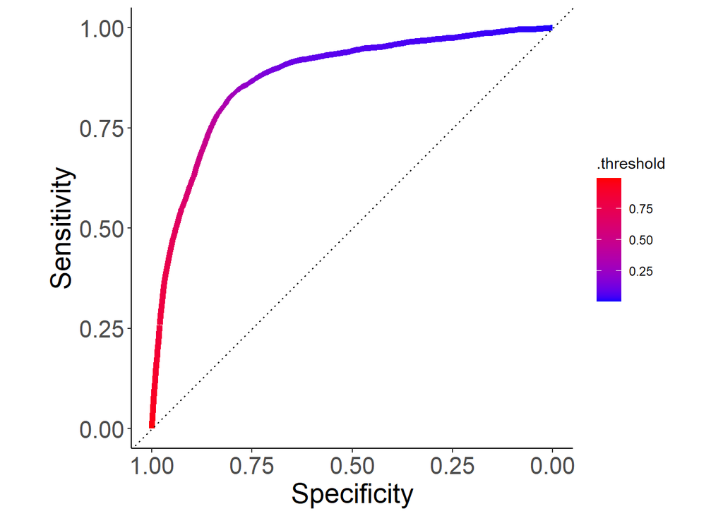

```r
roc_data <- preds_out %>%
  roc_curve(prob_beta, truth = label)

roc_data %>%
  ggplot(aes(x = 1 - specificity, y = sensitivity, color = .threshold)) +
  geom_path(linewidth = 2) +
  geom_abline(lty = 3) +
  coord_fixed(xlim = c(0, 1), ylim = c(0, 1)) +
  labs(x = "Specificity",
       y = "Sensitivity") +
  scale_x_continuous(breaks = seq(0,1,.25),
    labels = sprintf("%.2f", seq(1,0,-.25))) +
  scale_color_gradient(low="blue", high="red") +
  theme(axis.text = element_text(size = rel(1.50)),
        axis.title = element_text(size = rel(1.75)))
```

And these are the curves for each outer fold

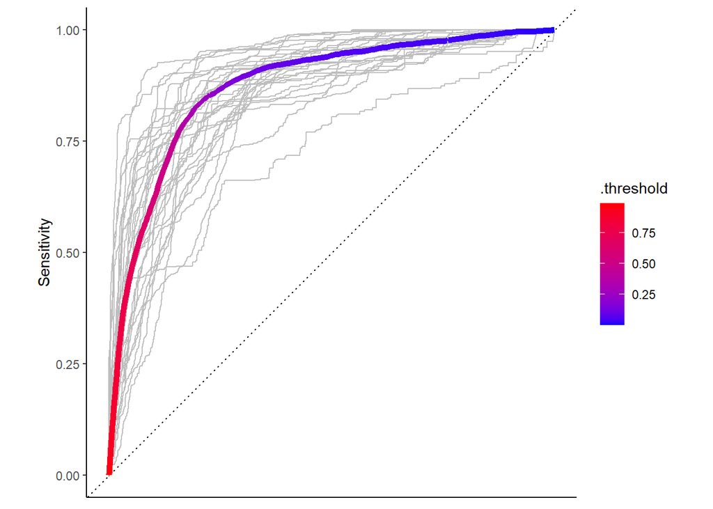

```r
# rocs per fold
roc_folds <- preds_out %>%
  nest(.by = outer_split_num, .key = "preds") |>
  mutate(roc = map(preds, \(preds) roc_curve(preds, prob_beta,
                                             truth = label)))

fig_roc_folds <- roc_data %>%  # plot region from full concatenated data
  ggplot(aes(x = 1 - specificity, y = sensitivity)) +
  geom_abline(lty = 3) +
  coord_fixed(xlim = c(0, 1), ylim = c(0, 1)) +
  labs(x = "Specificity",
       y = "Sensitivity") +
  scale_x_continuous(breaks = seq(0,1,.25),
    labels = sprintf("%.2f", seq(1,0,-.25))) +
  theme(axis.title.x=element_blank(),
        axis.text.x=element_blank(),
        axis.ticks.x=element_blank())

for (i in 1:nrow(roc_folds)) {
  fig_roc_folds <- fig_roc_folds +
     geom_path(data = roc_folds$roc[[i]],
               mapping = aes(x = 1 - specificity, y = sensitivity),
               color = "gray")
}

#add full concatenated curve
fig_roc_folds +
     geom_path(data = roc_data,
               mapping = aes(x = 1 - specificity, y = sensitivity, color = .threshold),
               linewidth = 2) +
    scale_color_gradient(low="blue", high="red")
```

#### Plot histogram of auROC test folds

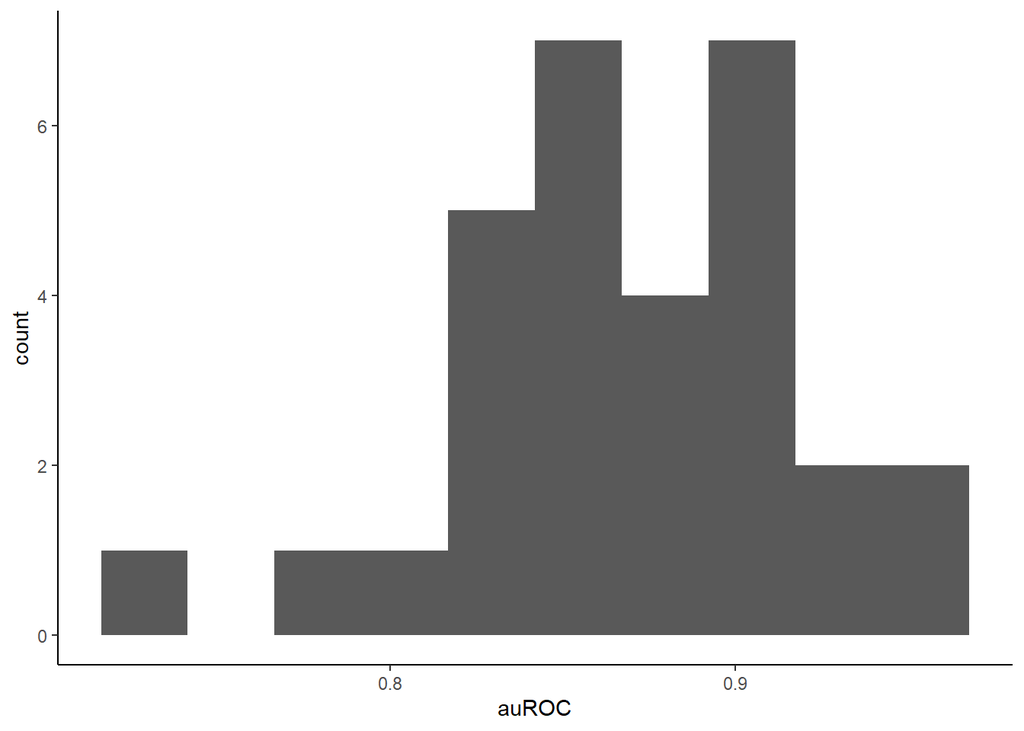

```r
metrics_test |>
  filter(.metric == "roc_auc") |>
  ggplot(aes(x = .estimate)) +
  geom_histogram(bins = 10) +
  xlab("auROC")
```

#### Probability Histograms

Histograms with free Y. Remove `scales = "free_y"` for fixed y but doesnt make sense to do this with the class imbalance

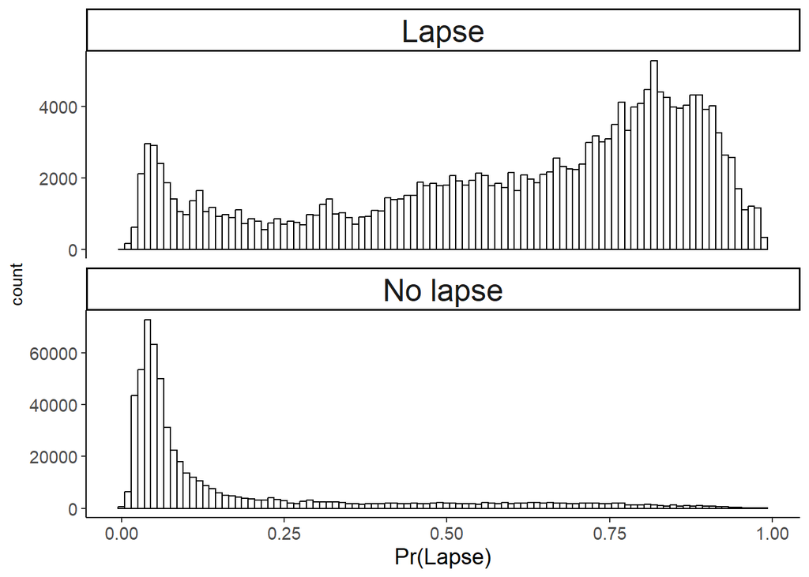

```r
preds_out %>%
  ggplot(data = ., aes(x = prob_beta)) +
   geom_histogram(bins = 100, fill = "white", col = "black") +
   facet_wrap(~label, nrow = 2, scales = "free_y") +
   xlab("Pr(Lapse)") +
  theme(axis.text = element_text(size = rel(1.00)),
        axis.title.x = element_text(size = rel(1.25)),
        strip.text = element_text(size = rel(1.75)))
```

#### Confusion matrices based on concatenated test folds

Confusion matrix using .5 threshold

```r
(cm <- preds_out |>
   mutate(estimate = if_else(prob_beta > .5, "Lapse", "No lapse"),
          estimate = factor(estimate, levels = c("Lapse", "No lapse"))) |>
   conf_mat(truth = label, estimate = estimate))
```

```
          Truth
Prediction  Lapse No lapse
  Lapse    135557    72428
  No lapse  60784   510160
```

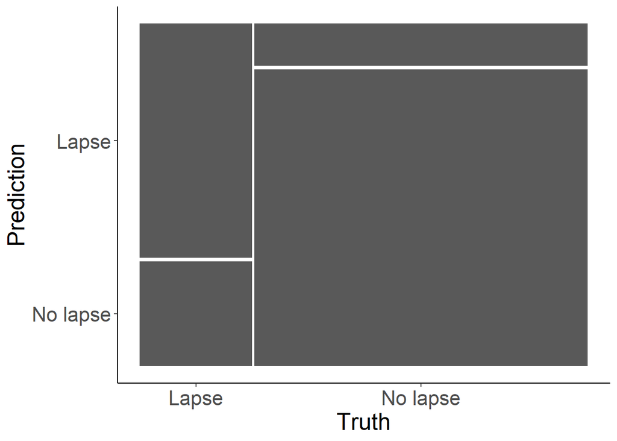

```r
cm %>%
  autoplot() +
  theme(axis.text = element_text(size = rel(1.50)),
        axis.title = element_text(size = rel(1.75)))
```

```r
cm %>% summary()
```

```
# A tibble: 13 × 3
   .metric              .estimator .estimate
   <chr>                <chr>          <dbl>
 1 accuracy             binary         0.829
 2 kap                  binary         0.555
 3 sens                 binary         0.690
 4 spec                 binary         0.876
 5 ppv                  binary         0.652
 6 npv                  binary         0.894
 7 mcc                  binary         0.556
 8 j_index              binary         0.566
 9 bal_accuracy         binary         0.783
10 detection_prevalence binary         0.267
11 precision            binary         0.652
12 recall               binary         0.690
13 f_meas               binary         0.671
```

```r
# save plot for presentations
# ggsave(file.choose(), width = 7.5, height = 6.5, units = "in", device = "png",  dpi = 100)
```

Confusion matrix at optimal cut-point (based on Youdens J index)

https://www.ncbi.nlm.nih.gov/pmc/articles/PMC1444894/ https://pubmed.ncbi.nlm.nih.gov/15405679/

```r
j_thres_roc <- roc_data |>
  mutate(j = sensitivity + specificity - 1) |>
  slice_max(j) |>
  print() |>
  pull(.threshold)
```

```
# A tibble: 1 × 4
  .threshold specificity sensitivity     j
       <dbl>       <dbl>       <dbl> <dbl>
1      0.289       0.802       0.830 0.633
```

```r
(cm <- preds_out |>
   mutate(estimate = if_else(prob_beta > j_thres_roc, "Lapse", "No lapse"),
          estimate = factor(estimate, levels = c("Lapse", "No lapse"))) |>
   conf_mat(truth = label, estimate = estimate))
```

```
          Truth
Prediction  Lapse No lapse
  Lapse    163005   115153
  No lapse  33336   467435
```

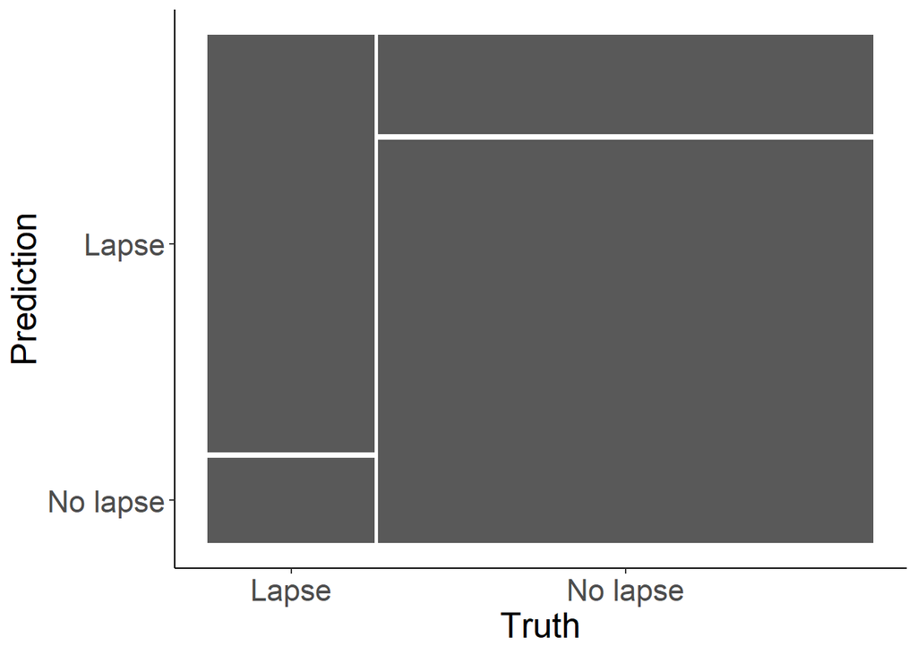

```r
cm %>%
  autoplot() +
  theme(axis.text = element_text(size = rel(1.50)),
        axis.title = element_text(size = rel(1.75)))
```

```r
cm %>% summary()
```

```
# A tibble: 13 × 3
   .metric              .estimator .estimate
   <chr>                <chr>          <dbl>
 1 accuracy             binary         0.809
 2 kap                  binary         0.556
 3 sens                 binary         0.830
 4 spec                 binary         0.802
 5 ppv                  binary         0.586
 6 npv                  binary         0.933
 7 mcc                  binary         0.573
 8 j_index              binary         0.633
 9 bal_accuracy         binary         0.816
10 detection_prevalence binary         0.357
11 precision            binary         0.586
12 recall               binary         0.830
13 f_meas               binary         0.687
```

#### PR Curve

Here is precision/recall by concatenating all folds. Same approach as above for ROC

```r
preds_out %>%
  pr_auc(prob_beta, truth = label)
```

```
# A tibble: 1 × 3
  .metric .estimator .estimate
  <chr>   <chr>          <dbl>
1 pr_auc  binary         0.697
```

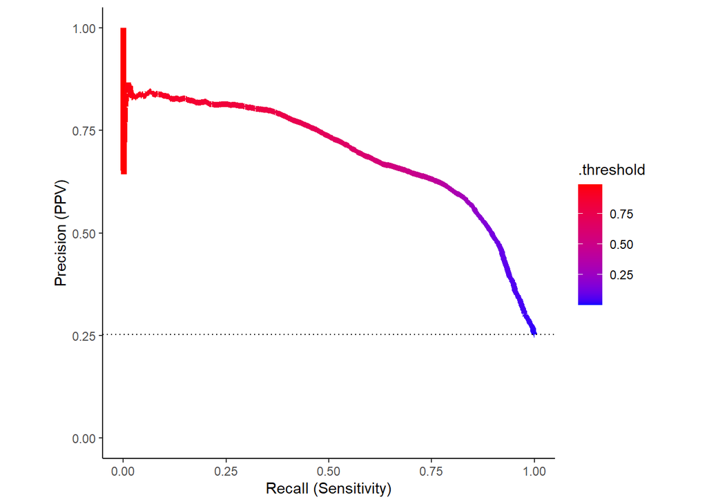

```r
pr_data <- preds_out %>%
  pr_curve(prob_beta, truth = label)

pr_data %>%
  ggplot(aes(x = recall, y = precision, color = .threshold)) +
  geom_path(linewidth = 2) +
  geom_hline(lty = 3, yintercept = mean(preds_out$label == "Lapse")) +
  coord_fixed(xlim = c(0, 1), ylim = c(0, 1)) +
  scale_color_gradient(low="blue", high="red") +
  labs(x = "Recall (Sensitivity)",
       y = "Precision (PPV)")
```

Sensitivity at min PPV of .7

```r
pr_data |>
  filter(precision >= .7) |>
  arrange(desc(recall)) |>
  slice(1) |>
  print()
```

```
# A tibble: 1 × 3
  .threshold recall precision
       <dbl>  <dbl>     <dbl>
1      0.627  0.567     0.700
```

Sensitivity at best F

```r
f <- pr_data |>
  mutate(f =  (2 * precision * recall) / (precision + recall)) |>
  slice_max(f) |>
  print()
```

```
# A tibble: 1 × 4
  .threshold recall precision     f
       <dbl>  <dbl>     <dbl> <dbl>
1      0.383  0.782     0.618 0.690
```

### Feature Importance

#### Grouped Features

```r
shapsgrp_out <- readRDS(here::here(path_models, str_c("outer_shapsgrp_",
                                                      window, "_", lead, "_",
                                                      version, "_", cv, "_",
                                                      model, ".rds")))
```

Global importance SHAP plot for grouped features

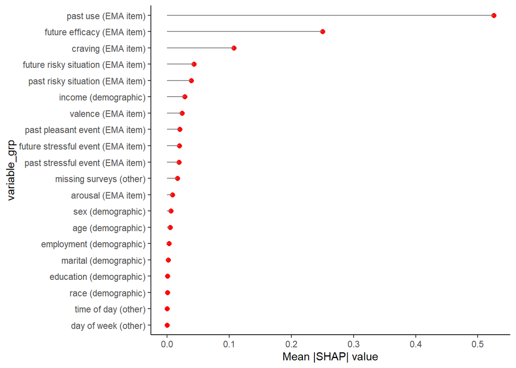

```r
shapsgrp_out %>%
  group_by(variable_grp) %>%
  summarize(mean_value = mean(abs(value)), .groups = "drop") %>%
  arrange(mean_value) %>%
  mutate(variable_grp = factor(variable_grp),
         variable_grp = fct_inorder(variable_grp)) %>%
  ggplot(mapping = aes(x = variable_grp, y = mean_value)) +
  geom_point(size = 2, color = "red") +
  geom_segment(aes(x = variable_grp, y = mean_value, xend = variable_grp),
               yend = 0, colour = "grey50")  +
  ylab("Mean |SHAP| value") +
  coord_flip()
```